# **Part A: Convolutional Neural Network**

This is how RestNet looks like:

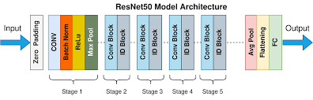

RestNet Idea:

- Bottleneck strucutre is used to reduce model parameters by alternating 1x1 and 3x3 covolutions
- Extract features at decreasing levels of resolution from conv2_x to conv5_x
- Stride=2 is used in the first 3x3 convolutions of the first residual blocks for conv3_x, conv4_x, and conv5_x to downsample feature maps to get larger receptive field.

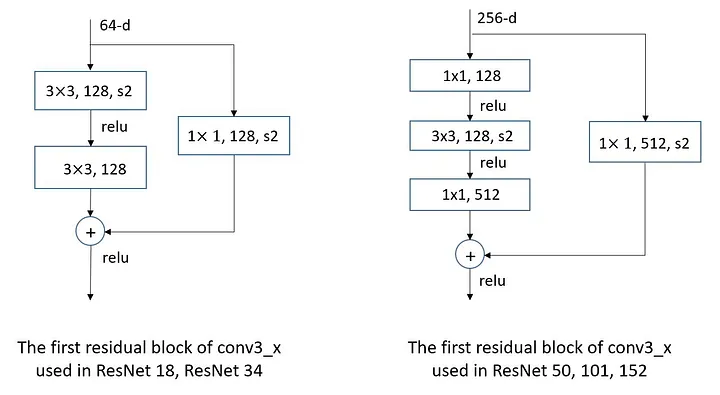

**My Implementation**

- Change the input size suitable for the 31 x 31 images

```python
def res_conv(x, s, filters):
    x_skip = x
    f1, f2 = filters

    # First block
    x = Conv2D(f1, kernel_size=(1, 1), strides=(s, s), padding='valid', kernel_regularizer=l2(0.001))(x)
    x = BatchNormalization()(x)
    x = Activation('relu')(x)

    # Second block
    x = Conv2D(f1, kernel_size=(3, 3), strides=(1, 1), padding='same', kernel_regularizer=l2(0.001))(x)
    x = BatchNormalization()(x)
    x = Activation('relu')(x)

    # Third block
    x = Conv2D(f2, kernel_size=(1, 1), strides=(1, 1), padding='valid', kernel_regularizer=l2(0.001))(x)
    x = BatchNormalization()(x)

    # Shortcut
    x_skip = Conv2D(f2, kernel_size=(1, 1), strides=(s, s), padding='valid', kernel_regularizer=l2(0.001))(x_skip)
    x_skip = BatchNormalization()(x_skip)

    # Add and activation
    x = Add()([x, x_skip])
    x = Activation('relu')(x)

    return x

def res_identity(x, filters):
    x_skip = x
    f1, f2 = filters

    # First block
    x = Conv2D(f1, kernel_size=(1, 1), strides=(1, 1), padding='valid', kernel_regularizer=l2(0.001))(x)
    x = BatchNormalization()(x)
    x = Activation('relu')(x)

    # Second block - bottleneck (but size kept the same with padding)
    x = Conv2D(f1, kernel_size=(3, 3), strides=(1, 1), padding='same', kernel_regularizer=l2(0.001))(x)
    x = BatchNormalization()(x)
    x = Activation('relu')(x)

    # Third block - activation used after adding the input
    x = Conv2D(f2, kernel_size=(1, 1), strides=(1, 1), padding='valid', kernel_regularizer=l2(0.001))(x)
    x = BatchNormalization()(x)

    # Add the input
    x = Add()([x, x_skip])
    x = Activation('relu')(x)

    return x

def resnet50(train_im, class_types):
    input_im = Input(shape=(31,31,1))
    x = ZeroPadding2D(padding=(3, 3))(input_im)

    # 1st stage
    x = Conv2D(64, kernel_size=(7, 7), strides=(2, 2))(x)
    x = BatchNormalization()(x)
    x = Activation('relu')(x)
    x = MaxPooling2D((3, 3), strides=(2, 2))(x)

    # 2nd stage
    x = res_conv(x, s=1, filters=(64, 256))
    x = res_identity(x, filters=(64, 256))
    x = res_identity(x, filters=(64, 256))

    # 3rd stage
    x = res_conv(x, s=2, filters=(128, 512))
    x = res_identity(x, filters=(128, 512))
    x = res_identity(x, filters=(128, 512))
    x = res_identity(x, filters=(128, 512))

    # 4th stage
    x = res_conv(x, s=2, filters=(256, 1024))
    x = res_identity(x, filters=(256, 1024))
    x = res_identity(x, filters=(256, 1024))
    x = res_identity(x, filters=(256, 1024))
    x = res_identity(x, filters=(256, 1024))
    x = res_identity(x, filters=(256, 1024))

    # 5th stage
    x = res_conv(x, s=2, filters=(512, 2048))
    x = res_identity(x, filters=(512, 2048))
    x = res_identity(x, filters=(512, 2048))

    # Ends with average pooling and dense connection
    x = AveragePooling2D((2, 2), padding='same')(x)
    x = Flatten()(x)
    x = Dense(len(class_types), activation='softmax', kernel_initializer='he_normal')(x)  # Multi-class

    # Define the model
    model = Model(inputs=input_im, outputs=x, name='Resnet50')

    model.summary()
    return model
```

#### Running the model

```python
restnet_model = resnet50(X_train_small, labels_dict)
restnet_model.compile(optimizer='adam', loss='categorical_crossentropy', metrics=['accuracy'])
restnet_model.summary()
```

```
Model: "Resnet50"
__________________________________________________________________________________________________
 Layer (type)                   Output Shape         Param #     Connected to
==================================================================================================
 input_1 (InputLayer)           [(None, 31, 31, 1)]  0           []

 zero_padding2d (ZeroPadding2D)  (None, 37, 37, 1)   0           ['input_1[0][0]']

 conv2d (Conv2D)                (None, 16, 16, 64)   3200        ['zero_padding2d[0][0]']

 batch_normalization (BatchNorm  (None, 16, 16, 64)  256         ['conv2d[0][0]']
 alization)

 activation (Activation)        (None, 16, 16, 64)   0           ['batch_normalization[0][0]']

 max_pooling2d (MaxPooling2D)   (None, 7, 7, 64)     0           ['activation[0][0]']

 conv2d_1 (Conv2D)              (None, 7, 7, 64)     4160        ['max_pooling2d[0][0]']

 batch_normalization_1 (BatchNo  (None, 7, 7, 64)    256         ['conv2d_1[0][0]']
 rmalization)

 activation_1 (Activation)      (None, 7, 7, 64)     0           ['batch_normalization_1[0][0]']

 conv2d_2 (Conv2D)              (None, 7, 7, 64)     36928       ['activation_1[0][0]']

 batch_normalization_2 (BatchNo  (None, 7, 7, 64)    256         ['conv2d_2[0][0]']
 rmalization)

 activation_2 (Activation)      (None, 7, 7, 64)     0           ['batch_normalization_2[0][0]']

 conv2d_3 (Conv2D)              (None, 7, 7, 256)    16640       ['activation_2[0][0]']

 conv2d_4 (Conv2D)              (None, 7, 7, 256)    16640       ['max_pooling2d[0][0]']

 batch_normalization_3 (BatchNo  (None, 7, 7, 256)   1024        ['conv2d_3[0][0]']
 rmalization)

 batch_normalization_4 (BatchNo  (None, 7, 7, 256)   1024        ['conv2d_4[0][0]']
 rmalization)
```

[output cut: 811 more lines]

```

 activation_48 (Activation)     (None, 1, 1, 2048)   0           ['add_15[0][0]']

 average_pooling2d (AveragePool  (None, 1, 1, 2048)  0           ['activation_48[0][0]']
 ing2D)

 flatten (Flatten)              (None, 2048)         0           ['average_pooling2d[0][0]']

 dense (Dense)                  (None, 15)           30735       ['flatten[0][0]']

==================================================================================================
Total params: 23,612,175
Trainable params: 23,559,055
Non-trainable params: 53,120
__________________________________________________________________________________________________
```

```python
results_restnet, fig_restnet = evaluator.model_evaluate( train_ds, val_ds , restnet_model, base_hparams)
```

#### Analysing the graph

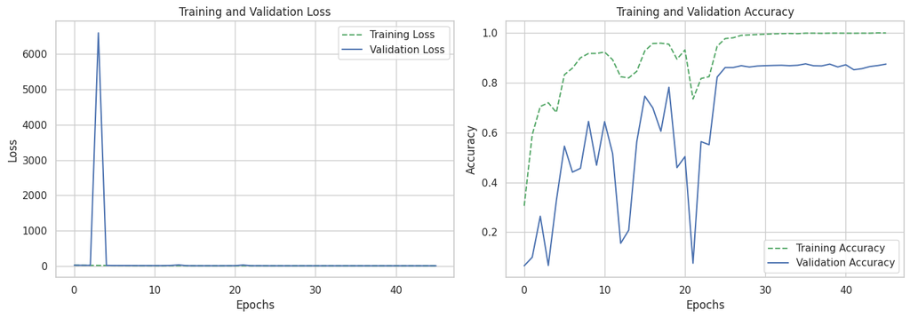

```python
fig_restnet()
```

```python
pd.Series(results_restnet)
```

```
Model Name    Resnet50
Epochs              46
Batch Size         128
Train Loss    3.042697
Test Loss     3.611549
Train Acc     0.998892
Test Acc      0.875667
dtype: object
```

*Things Observed*